# Soft Sediment Summaries

#### Softshell clam

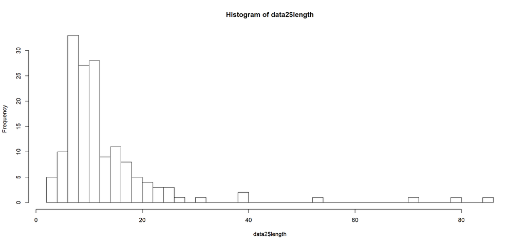

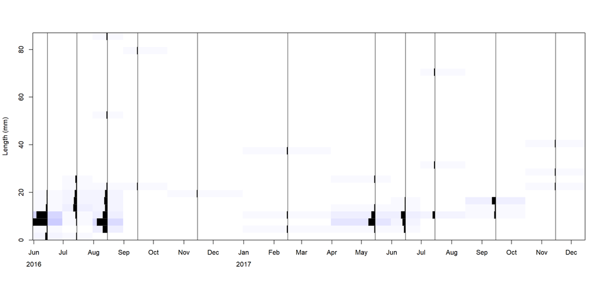

```r
lfq_year_month("myac", "")
```

#### Pacific littleneck clam

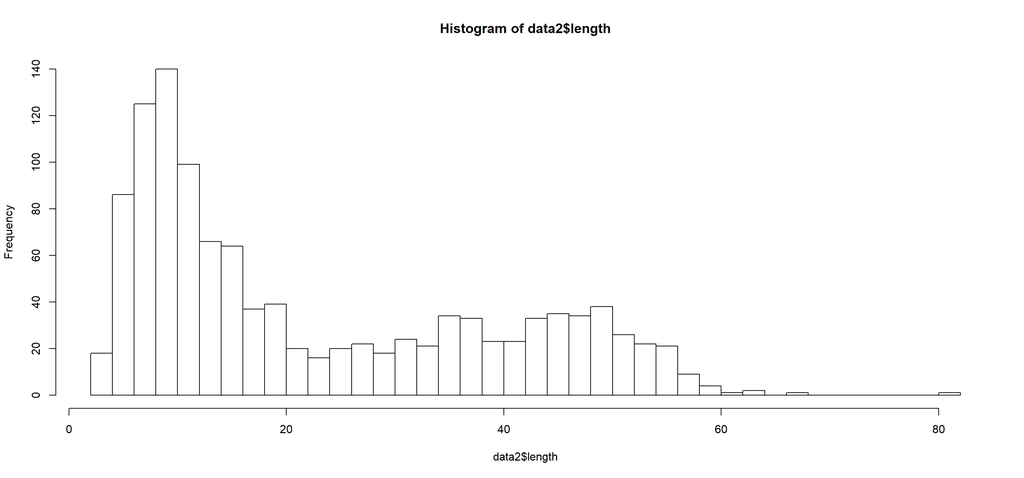

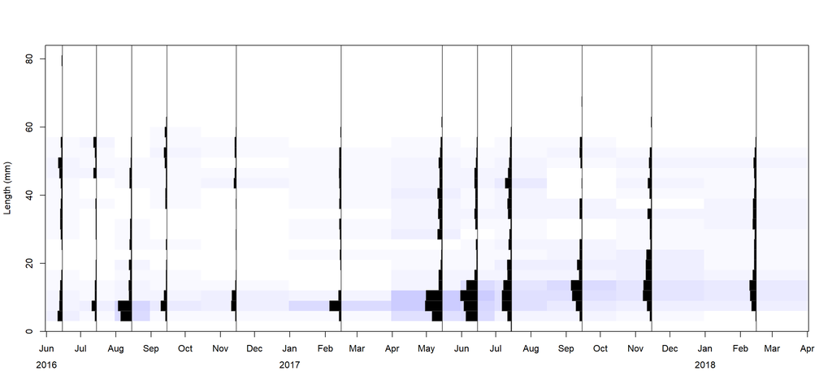

```r
lfq_year_month("plne", "")
```

#### Pointed macoma

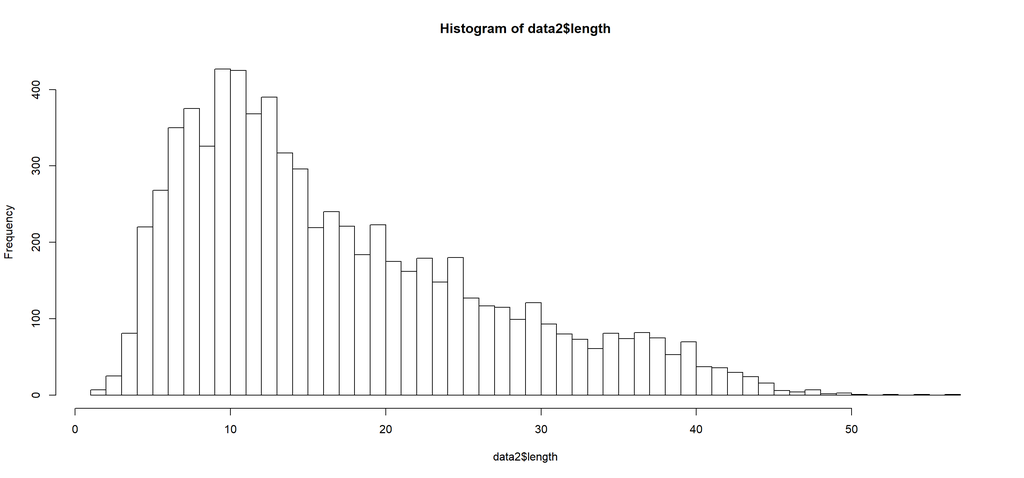

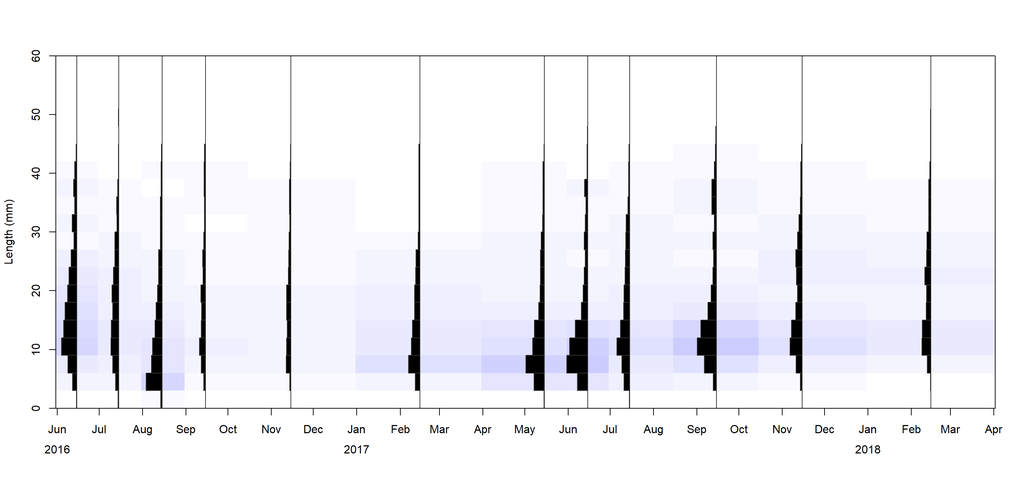

```r
lfq_year_month("pmac", "umac")
```

#### Juvenile macoma growth

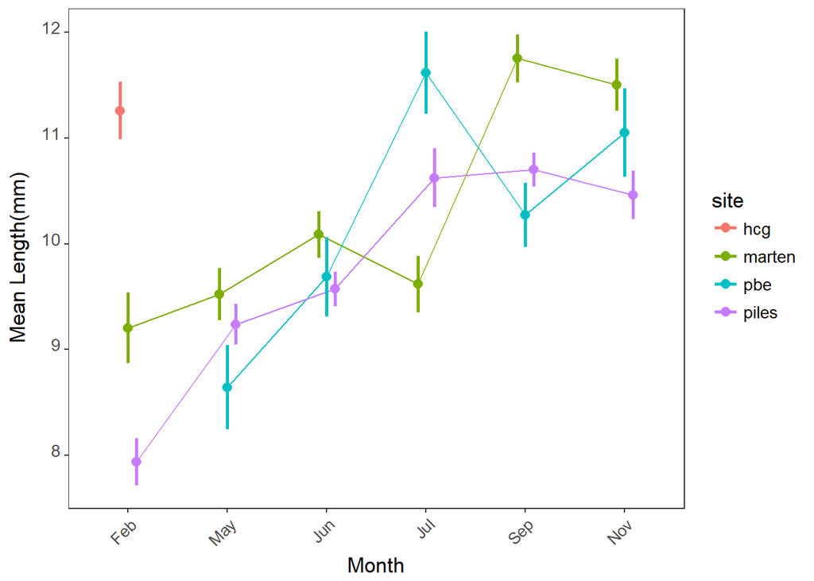

```r
mean_length_seasonal("umac",2017)
```

# Epifauna

Invertebrate diversity and abundance are presented in several different formats. Most invertebrates were identified to higher levels of classification.

```r
source("C:/Users/FABS/Desktop/Rwd_Ben/Soft_sed/working_files/Rscript/Soft_sediment/invert_base.R")
```

## Diversity

```r
source("C:/Users/FABS/Desktop/Rwd_Ben/Soft_sed/working_files/Rscript/Soft_sediment/invert_diversity.R")
```

### Species Accumulation Curve

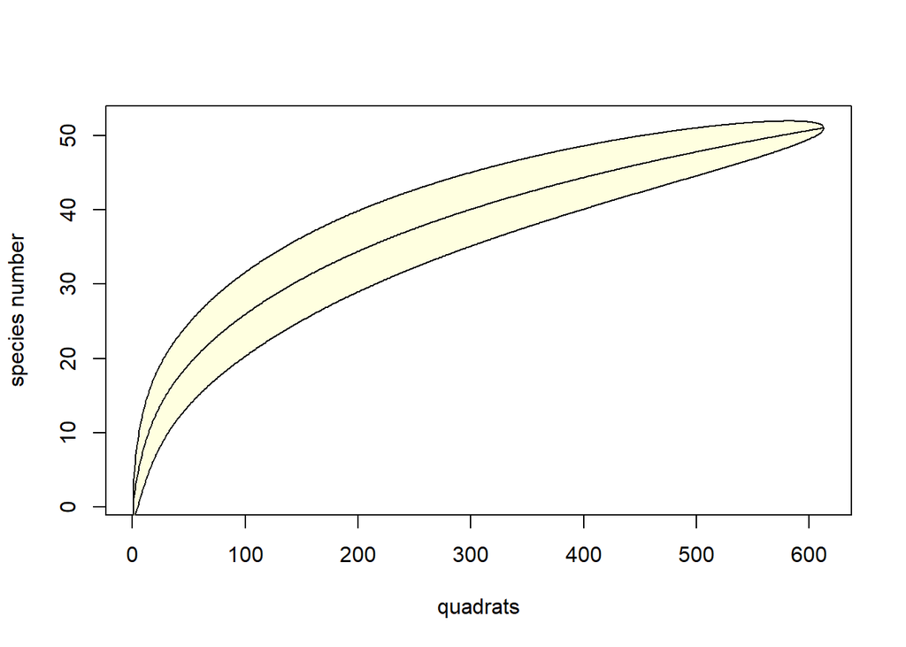

```r
invert_species_accumulation
```

### Seasonal Species Richness

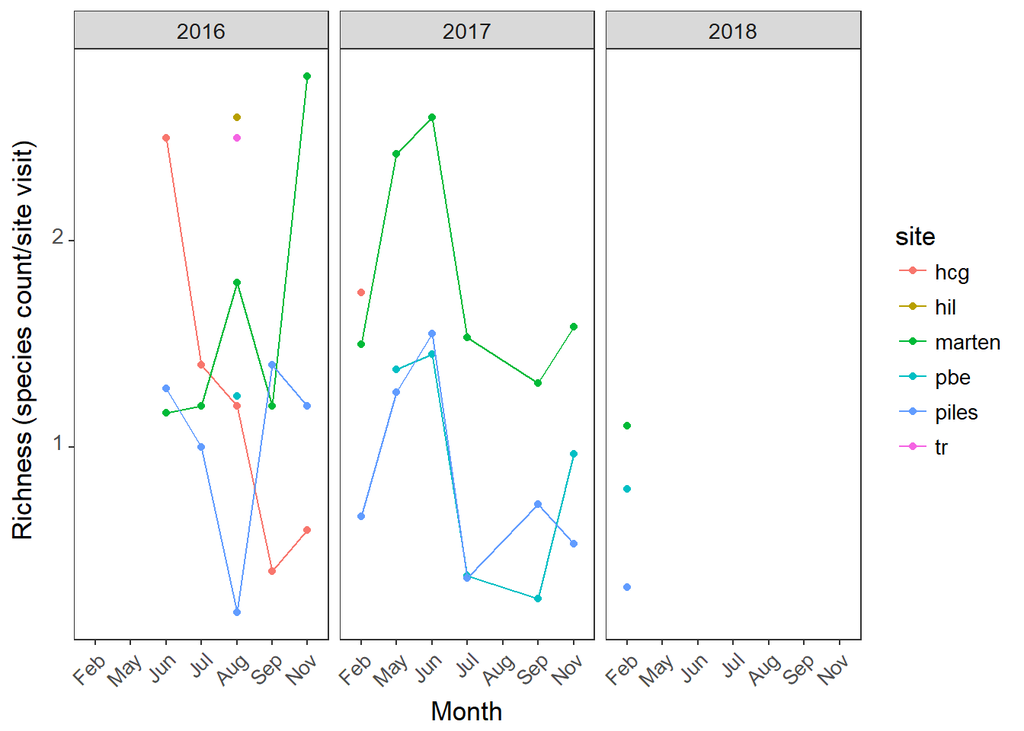

```r
invert_seasonal_species_richness
```

### Seasonal Shannons H

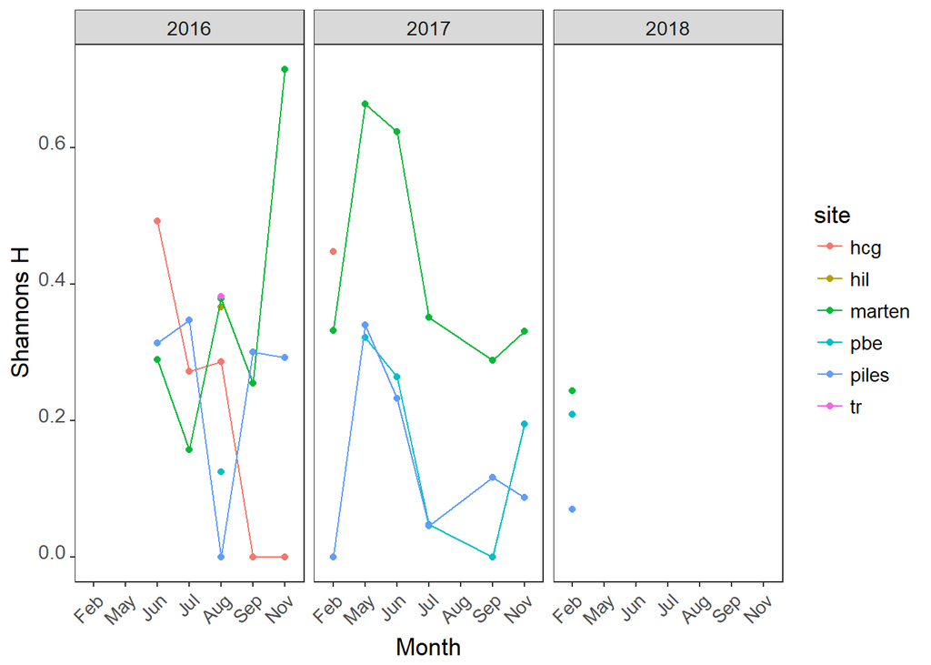

```r
invert_seasonal_shannons
```

### Species Richness by tide height

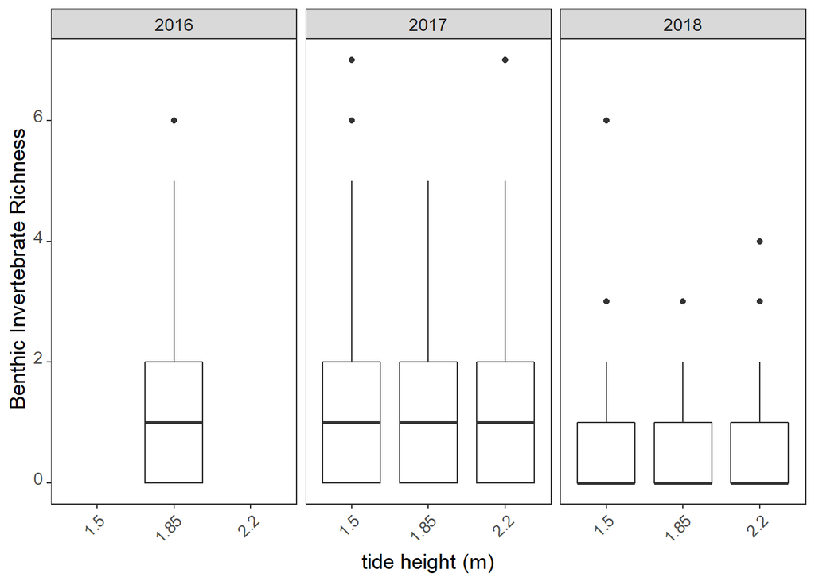

```r
invert_tidal_richness
```

### Invertebrate abundance by tide height

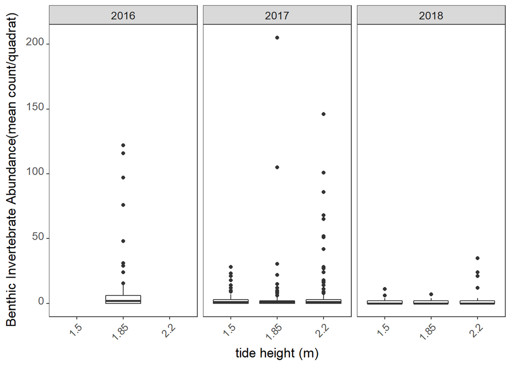

```r
invert_tidal_abundance
```

## Individual Species

These figures display 2017 seasonal abundance by tide height of some of the more common species.

### Amphipods

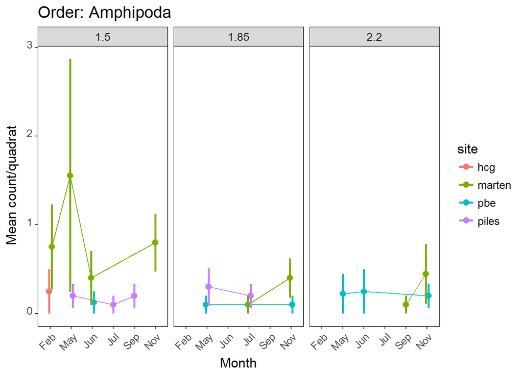

```r
invert_abundance_seasonal("amph", "Order: Amphipoda")
```

### Threaded bittium

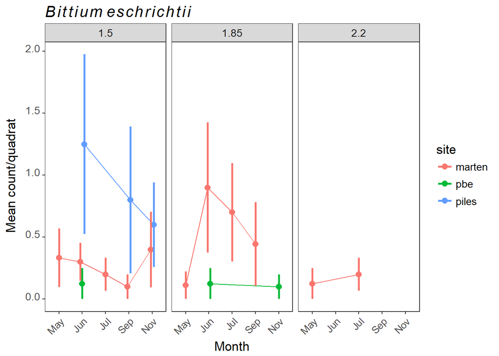

```r
invert_abundance_seasonal("thbi", expression(italic(Bittium~eschrichtii)))
```

### Acorn Barnacle

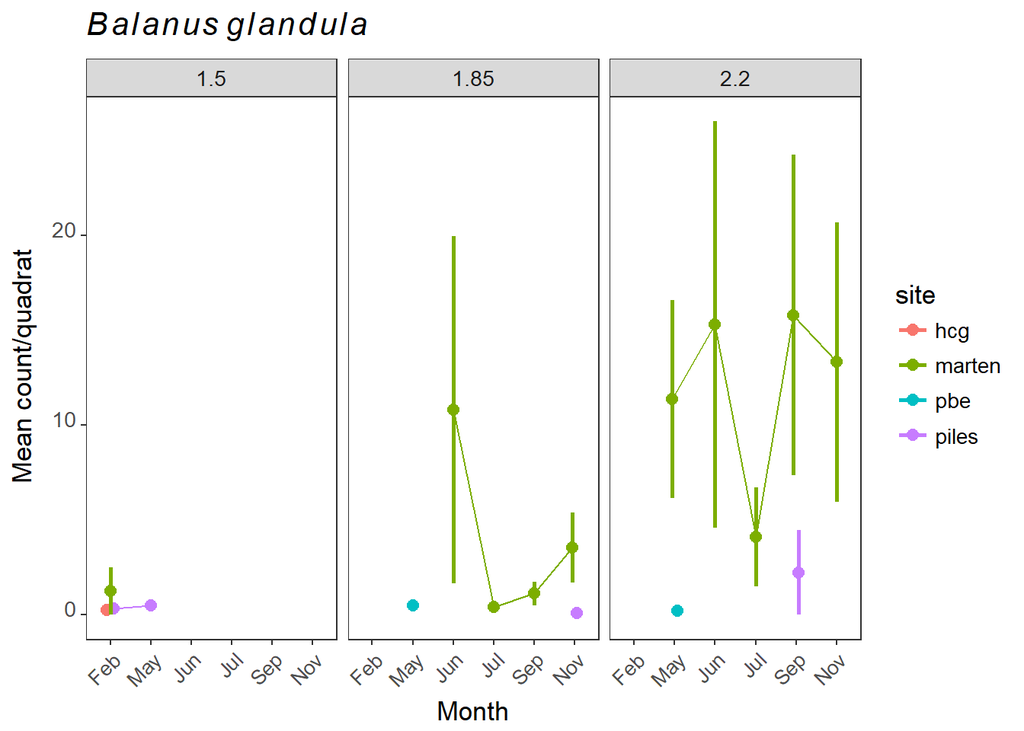

```r
invert_abundance_seasonal("bagl", expression(italic(Balanus~glandula)))
```

### Limpets

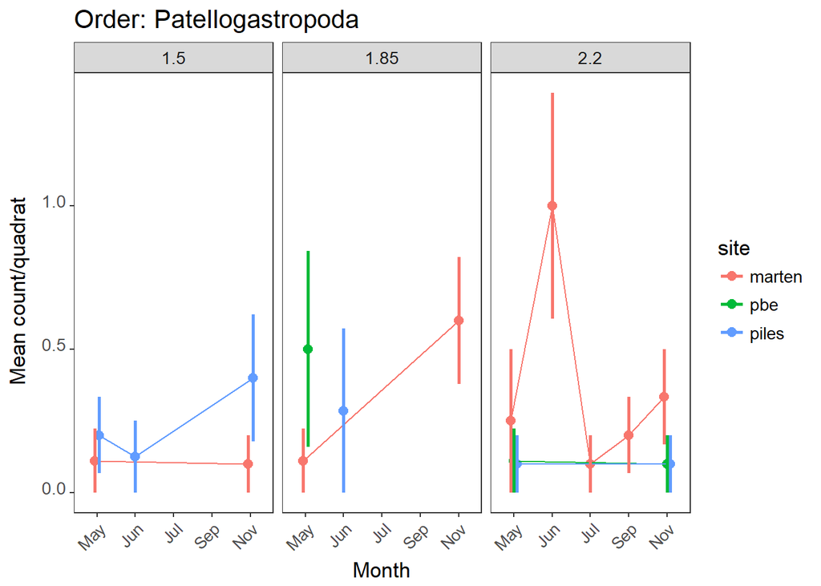

```r
invert_abundance_seasonal("limp", "Order: Patellogastropoda")
```

### Mussel

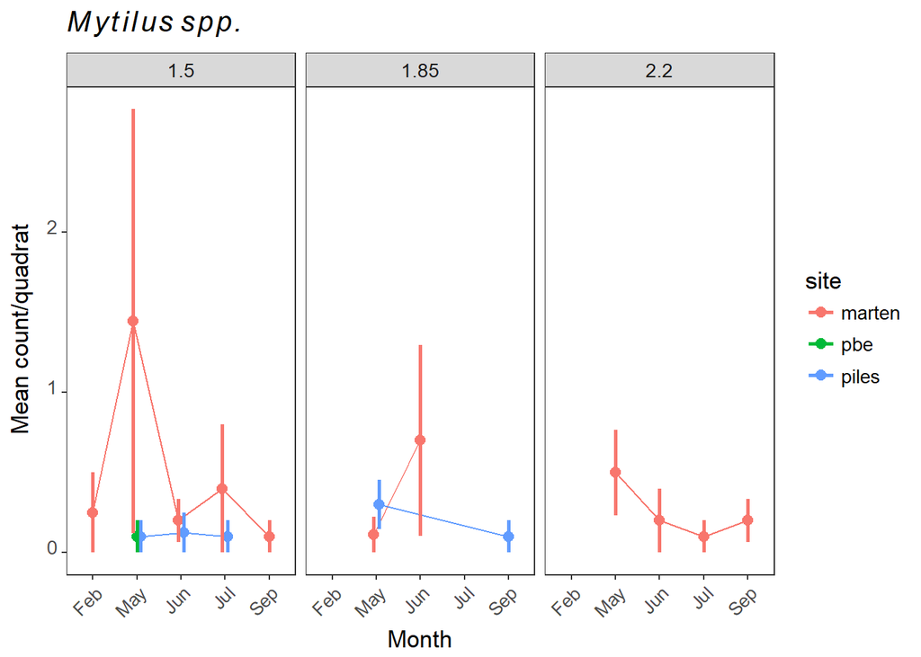

```r
invert_abundance_seasonal("myti", expression(italic(Mytilus~spp.)))
```

### Polychaetes

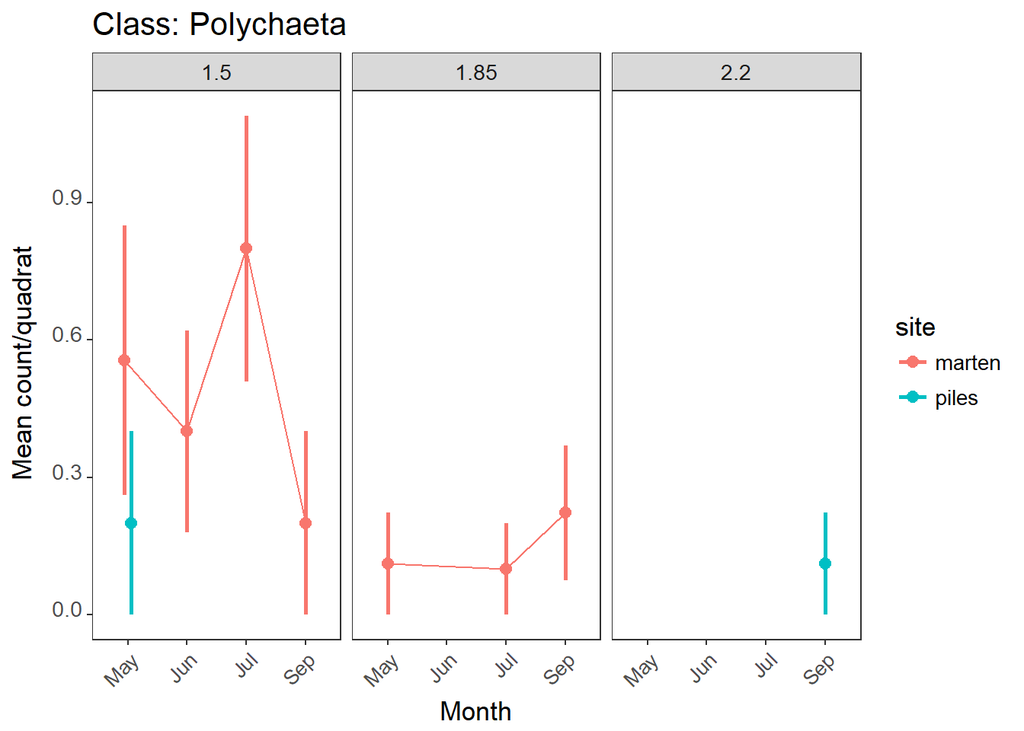

```r
invert_abundance_seasonal("poly", "Class: Polychaeta")
```

### Purple dwarf-venus

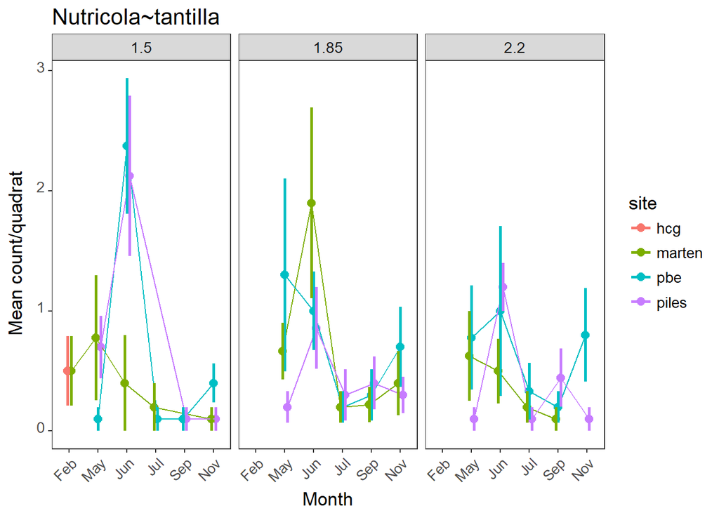

```r
invert_abundance_seasonal("puve", "Nutricola~tantilla")
```

### Roundworms

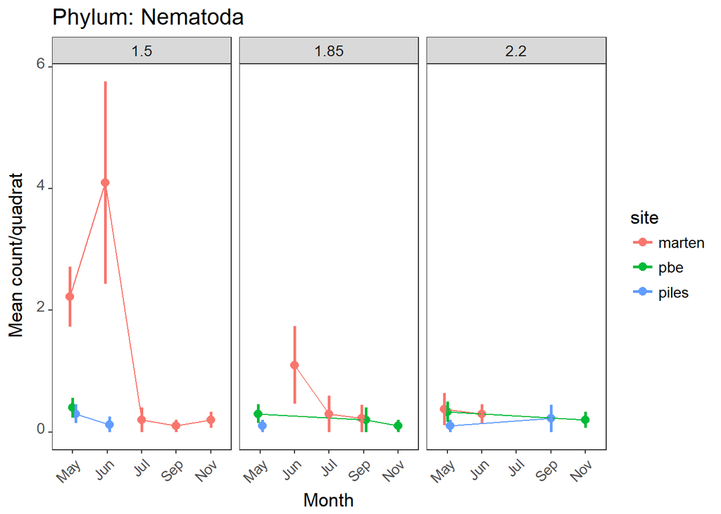

```r
invert_abundance_seasonal("rowo", "Phylum: Nematoda")
```

### Checkered periwinkle

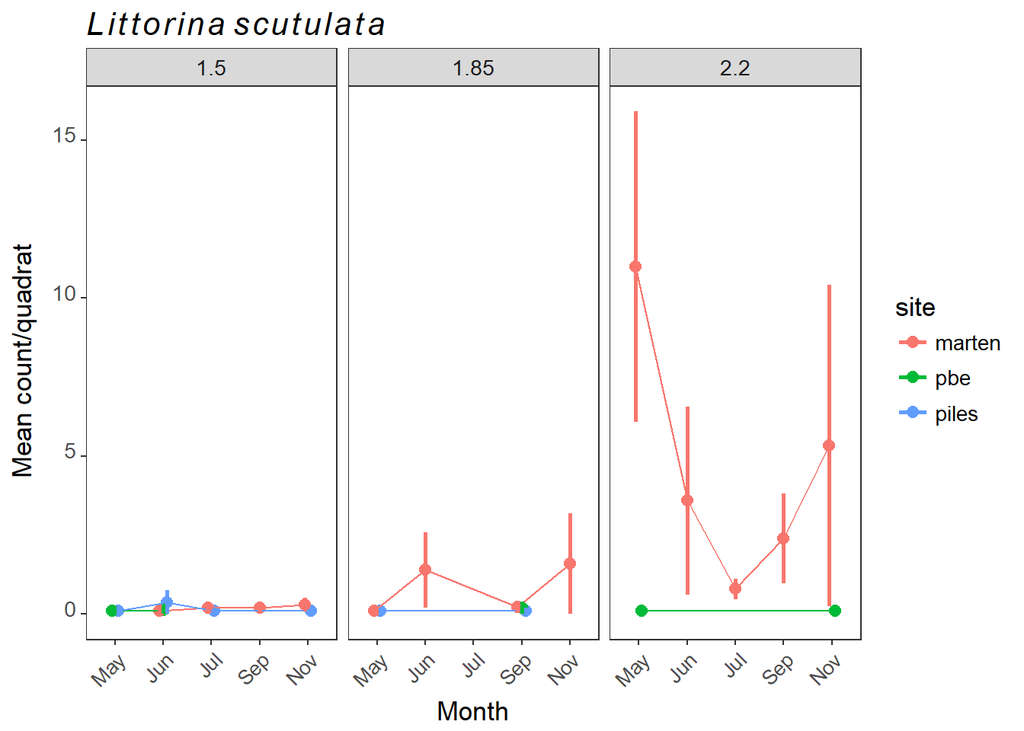

```r
invert_abundance_seasonal("scut", expression(italic(Littorina~scutulata)))
```

### Flatworms

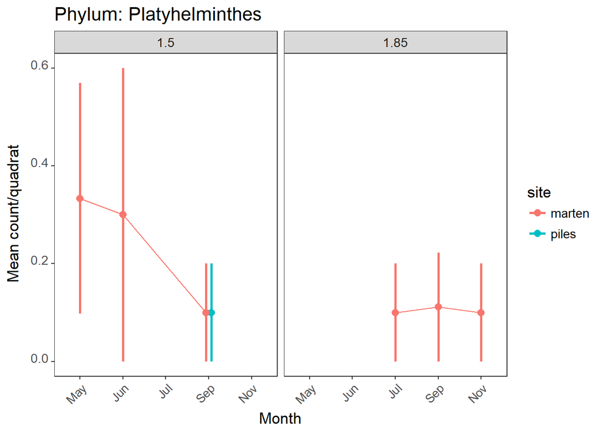

```r
invert_abundance_seasonal("flat", "Phylum: Platyhelminthes")
```

# Macrophytes

These figures present seasonal percent cover of individual species and all macrophytes combined.

```r
source("C:/Users/FABS/Desktop/Rwd_Ben/Soft_sed/working_files/Rscript/Soft_sediment/macro_base.R")
source("C:/Users/FABS/Desktop/Rwd_Ben/Soft_sed/working_files/Rscript/Soft_sediment/macro_cover.R")
```

## Sea Lettuce

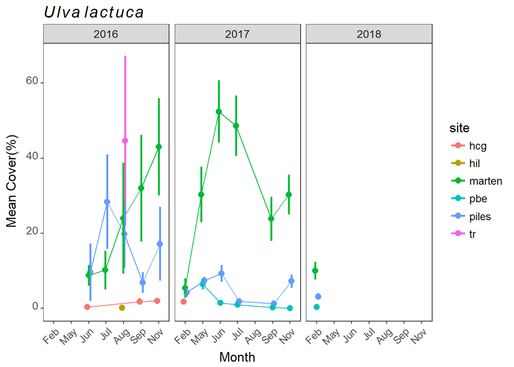

```r
mean_cover_seasonal("ulva", expression(italic(Ulva~lactuca)))
```

## Gutweed

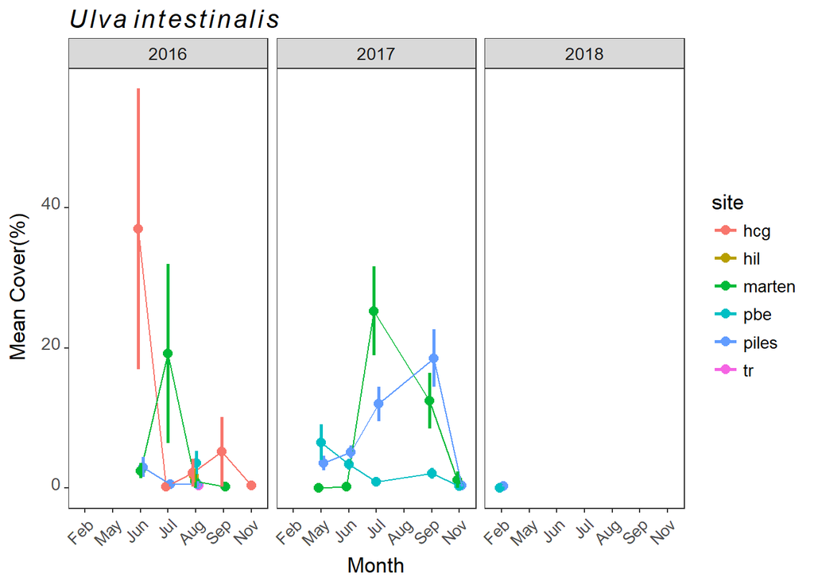

```r
mean_cover_seasonal("ulin", expression(italic(Ulva~intestinalis)))
```

## Gracilaria

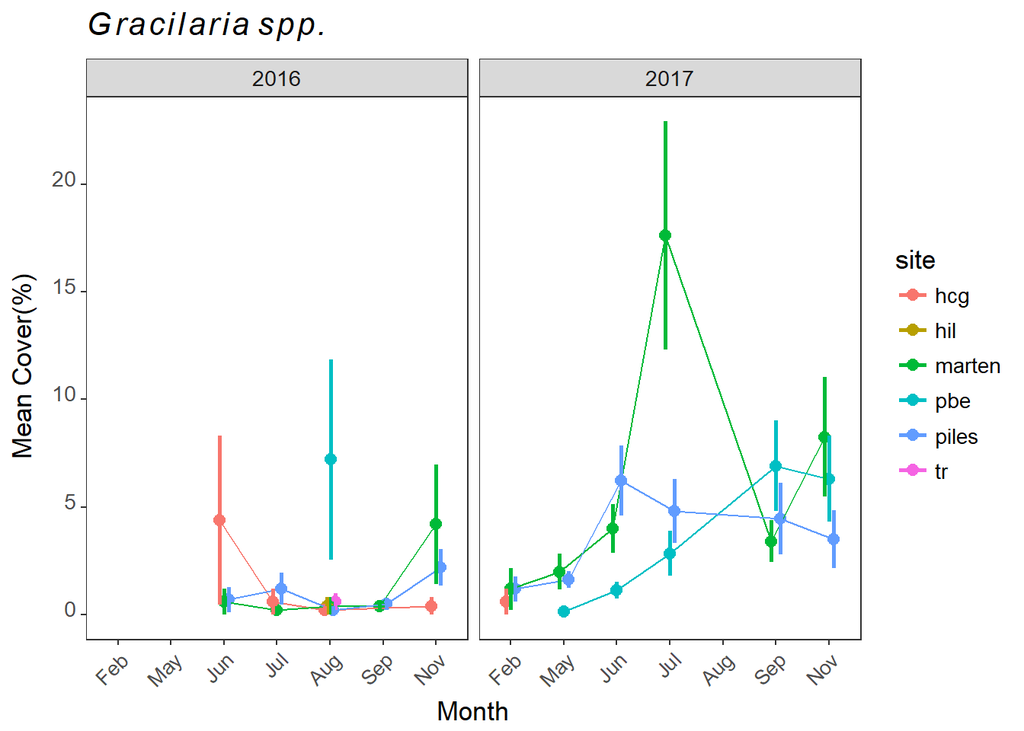

```r
mean_cover_seasonal("gras", expression(italic(Gracilaria~spp.)))
```

## Seagrass

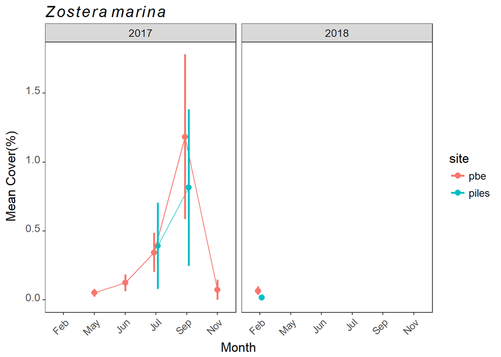

```r
mean_cover_seasonal("zost", expression(italic(Zostera~marina)))
```

## Total Cover

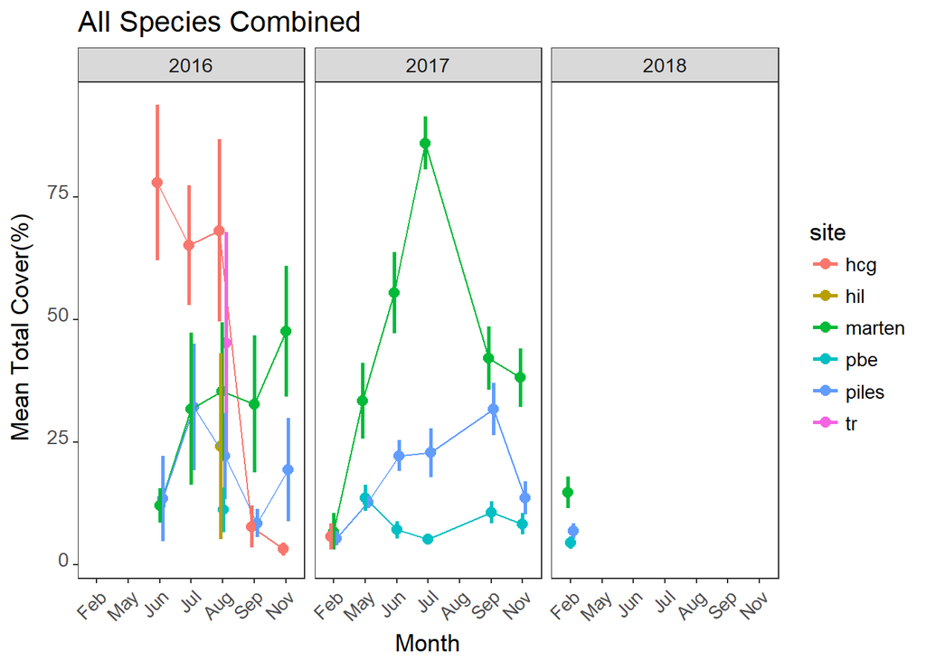

```r
ma_total_cover
```

# Temperature

```r
source("C:/Users/FABS/Desktop/Rwd_Ben/Soft_sed/working_files/Rscript/Soft_sediment/temp20152017.R")
```

These figures summarise temperaturde data collected by ibuttons(EIRP Lab) and hobo loggers(Hakai Nearshore) for 2015-2017. There are several months of missing data in 2016 when neither programs had loggers installed.

These loggers are installed in the intertidal zone at 2.2m(mlt) and have been trimmed of their “dry times”.

Temperature at depth intervals is also presented. This was achieved by selecing data at specific tide heights. This informs about mixing at these sites.

## Monthly Temperature

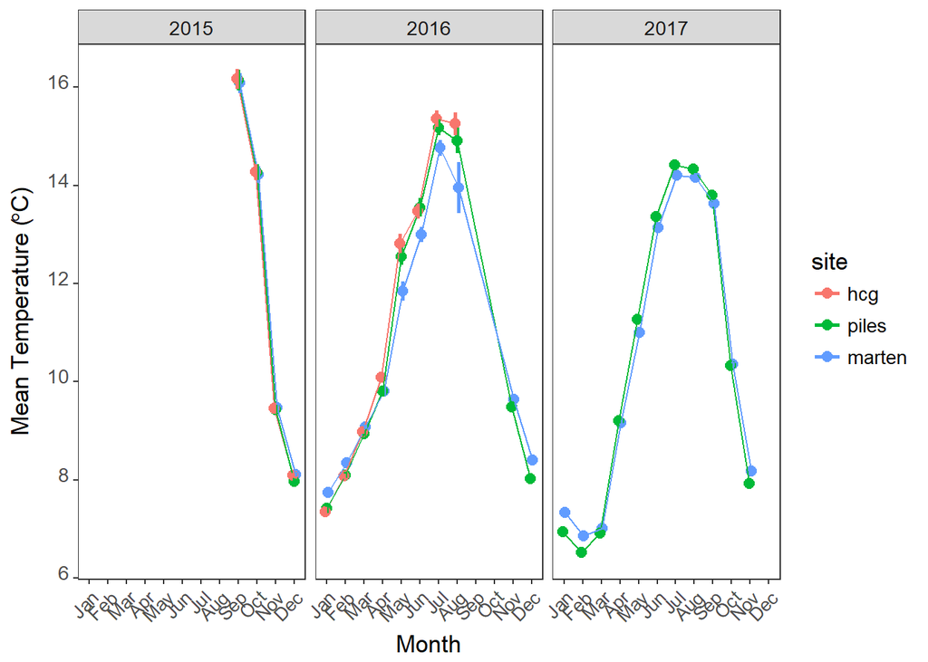

```r
temp_monthly
```

## Marten: temperature by depth

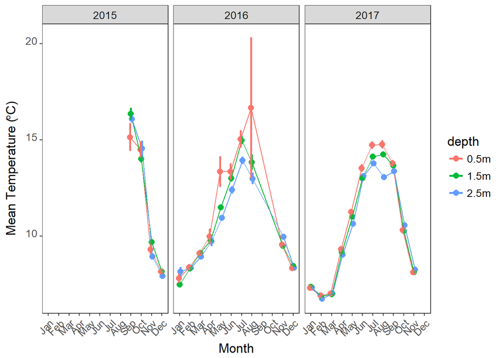

```r
temp_Marten
```

Temperature at depth intervals.

## Pruth: temperature by depth

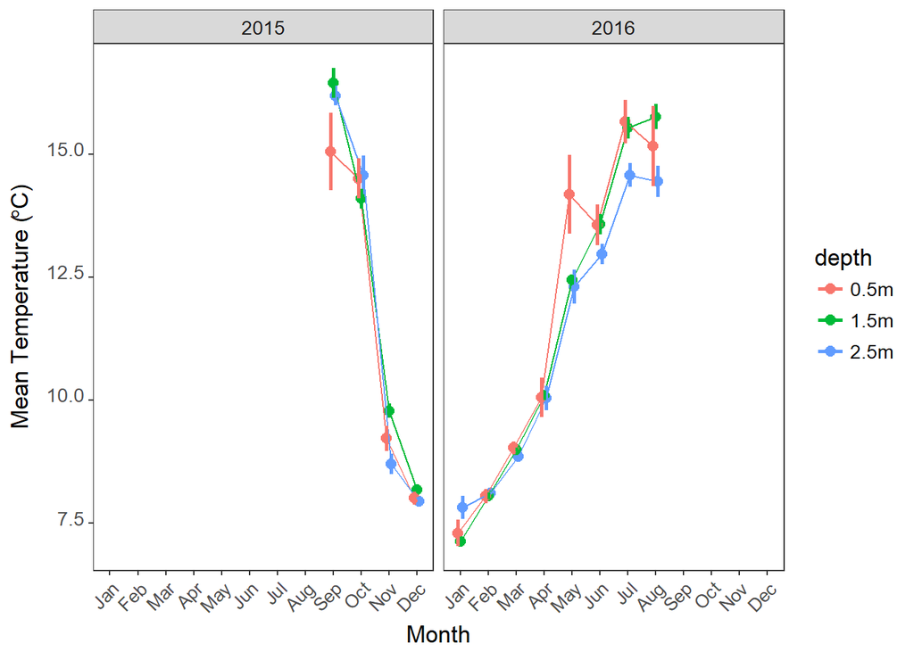

```r
temp_Pruth
```

## Piles: temperature by depth

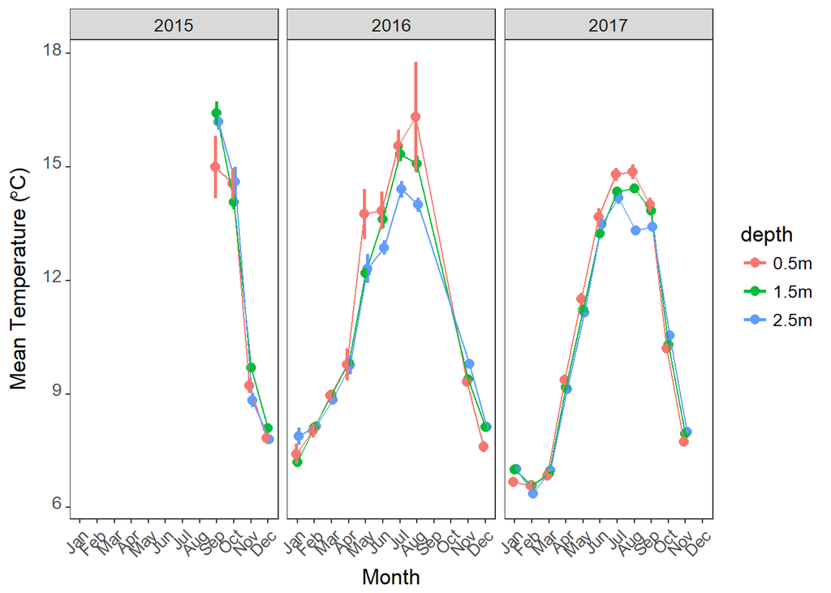

```r
temp_Piles
```

# Chlorophyll

Sediment chlorophyll a concentrations were measured at monthly intervals along with seasonal sampling events.

```r
source("C:/Users/FABS/Desktop/Rwd_Ben/Soft_sed/working_files/Rscript/Soft_sediment/chlorophyll.R")
```

## All sites

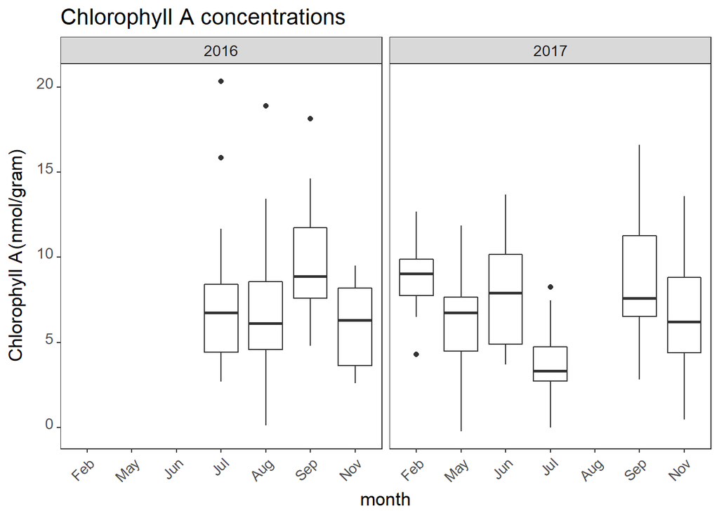

```r
chla
```

Chlorophyll A concentrations measured in nanomoles per gram sediment. All sites combined for 2016-2017.

## All sites

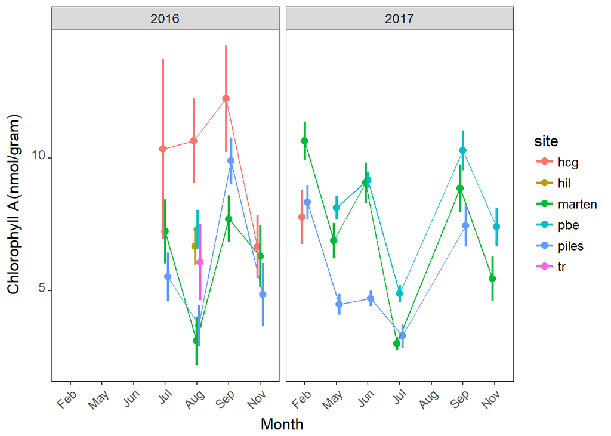

```r
chla_bysite
```

Chlorophyll A concentrations measured in nanomoles per gram sediment. All sites for 2016-2017.